# R Notebook

# ———————————————————-

# Set the base directory for your analysis

# ———————————————————-

```r
library(BSFG)
```

# ———————————————————-

# The following code generates simulated data, and then loads it into the R workspace

# can be skipped if you are loading your own data in a different way

# ———————————————————-

```r
seed = 1  # for reproducibility
nSire = 50 # simulation design is a half-sib design: each of nSire fathers has nRep children, each with a different female
nRep = 10
nTraits = 100
nFixedEffects = 2 # fixed effects are effects on the factors
nFactors = 10
factor_h2s = c(rep(0,nFactors/2),rep(0.9,nFactors/2))  # factor_h2 is the % of variance in each factor trait that is explained by additive genetic variation.
# The is after accounting for the fixed effects on the factors
Va = 2 # residual genetic variance in each of the observed traits after accounting for the factors
Ve = 2 # residual microenvironmental variance in each of the observed traits after accounting for the factors
Vb = 0 # magnitude of the fixed effects (just factors)
new_halfSib_simulation('Sim_FE_1', nSire=nSire,nRep=nRep,p=nTraits, b=nFixedEffects, factor_h2s= factor_h2s,Va = Va, Ve = Ve,Vb = Vb)
set.seed(seed)
load('setup.RData')
```

```r
Y = setup$Y
data = setup$data
K = setup$K
Y[1:(nrow(Y)*3/4),1:(ncol(Y)/4)] = NA
# Y[(nrow(Y)/4)+1:(nrow(Y)/4),(ncol(Y)/4)+1:(ncol(Y)/4)] = NA
# Y[2*(nrow(Y)/4)+1:(nrow(Y)/4),2*(ncol(Y)/4)+1:(ncol(Y)/4)] = NA
# Y[3*(nrow(Y)/4)+1:(nrow(Y)/4),3*(ncol(Y)/4)+1:(ncol(Y)/4)] = NA
```

# ———————————————————-

# Set the parameters of the BSFG model

# see ?BSFG_control

# ———————————————————-

```r
run_parameters = BSFG_control(
  max_NA_groups = 3,
  scale_Y = FALSE,   # should the columns of Y be re-scaled to have mean=0 and sd=1?
  simulation = TRUE, # Are you running against simulated data (ex from a call to new_halfSib_simulation above)? If so, you can provide the setup list and it will make some QC plots
  h2_divisions = 20, # Each variance component is allowed to explain between 0% and 100% of the total variation. How many segments should the range [0,100) be divided into for each random effect?
  h2_step_size = NULL, # if NULL, all possible values of random effects are tried each iteration. If in (0,1), a new candidate set of random effect proportional variances is drawn uniformily with a range of this size
  burn = 00,  # number of burn in samples before saving posterior samples
  K = 15 # number of factors
)
```

# ———————————————————-

# Set the prior hyperparameters of the BSFG model

# see ?BSFG_control

# ———————————————————-

```r
priors = BSFG_priors(
  tot_Y_var = list(V = 0.5,   nu = 5),      # Prior variance of trait residuals after accounting for fixed effects and factors
  tot_F_var = list(V = 18/20, nu = 20),     # Prior variance of factor traits. This is included to improve MCMC mixing, but can be turned off by setting nu very large
  Lambda_prior = list(
    sampler = sample_Lambda_prec_horseshoe,
    prop_0 = 0.1,
    delta_l = list(shape = 3, rate = 1),
    delta_iterations_factor = 100
  ),
  B2_prior = list(
    sampler = sample_B2_prec_horseshoe,
    prop_0 = 0.1
  ),
  cis_effects_prior = list(
    prec = 1
  ),
  h2_priors_resids_fun = function(h2s,n)  1,  # Function that returns the prior density for any value of the h2s vector (ie the vector of random effect proportional variances across all random effects. 1 means constant prior. Alternative: pmax(pmin(ddirichlet(c(h2s,1-sum(h2s)),rep(2,length(h2s)+1)),10),1e-10),
  h2_priors_factors_fun = function(h2s,n) 1 # See above. Another choice is one that gives 50% weight to h2==0: ifelse(h2s == 0,n,n/(n-1))
)
```

# ———————————————————-

# Construct the model

# see ?BSFG_init

# ———————————————————-

```r
options(error=recover)
BSFG_state = setup_model_BSFG(Y,            # n x p data matrix
                              ~(1|animal),  # RHS of base model for factors and residuals. Fixed effects defined here only apply to the factor residuals.
                              extra_regressions = list(X = model.matrix(~Fixed1,data)[,-1,drop=FALSE],factors=T,resids=F), # design matrix for additional fixed effects. These coefficients will be regularized with the B2_prior above. The same model can be used for both factors and resids
                              data,         # the data.frame with information for constructing the model matrices
                              relmat = list(animal = K), # covariance matrices for the random effects. If not provided, assume uncorrelated
                              run_parameters=run_parameters,
                              setup = setup, # only if running simulated data. Stores simulated values for comparison
                              run_ID = 'BSFG_example'
                                )
```

```
'BSFG_example' already exists
```

```r
maps = make_Missing_data_map(BSFG_state)
```

```
  map N_groups max_group_size total_kept_NAs
1   1        1            500           9375
  map N_groups max_group_size total_kept_NAs
1   2        2            125              0
```

```r
BSFG_state = set_Missing_data_map(BSFG_state,maps$Missing_data_map)
BSFG_state = set_priors_BSFG(BSFG_state,priors)
BSFG_state = initialize_variables_BSFG(BSFG_state)
```

```
[1] "initializing Lambda_prec regularized horseshoe"
[1] "initializing B_prec regularized horseshoe"
```

```r
BSFG_state = initialize_BSFG(BSFG_state)
```

```
[1] "Pre-calculating random effect inverse matrices for 2 groups of traits and 20 sets of random effect weights"
```

```r
BSFG_state = clear_Posterior(BSFG_state)
```

# ———————————————————-

# Run MCMC

# see ?sample_BSFG

# A MCMC chain is a way of fitting parameters from a Bayesian model

# The chain is a sequence of draws from the Posterior distribution of each parameter.

# BSFG uses a Gibbs sampler, which means that we iterate through all of the model’s parameters

# and for each parameter draw a new value from it’s posterior holding all other parameters constant

# This works, but the individual draws are not independent draws from the joint posterior of all parameters.

# Therefore, to get independent draws, we have to collect many posterior samples, and then save only a portion of them.

# Also, it may take many iterations for the MCMC chain to converge to the central part of the distribution.

# This is the burnin period, and we do not store these values (they are not useful).

# At the end, we have a collection of samples from the posterior distribution of each parameter.

# We can use these samples to characterize each distribution: mean, SD, histogram, HPDinterval, etc.

# The way BSFG works is that you ask the program to collect a small number of samples

# And then can assess how the chain is performing (how well it is mixing, is it converged?)

# And then either save the samples as posterior samples, or declare them as burn-in and discard them.

# Then, you can ask for more samples, and repeat until you have enough.

# ———————————————————-

# Tools for re-setting Posterior samples, and helping chain converge

# BSFG_state = clear_Posterior(BSFG_state)

# BSFG_state = reorder_factors(BSFG_state)

```r
n_samples = 200;  # how many samples to collect at once?
for(i  in 1:70) {
  print(sprintf('Run %d',i))
  BSFG_state = sample_BSFG(BSFG_state,n_samples,grainSize=1)  # run MCMC chain n_samples iterations. grainSize is a paramter for parallelization (smaller = more parallelization)

  BSFG_state = save_posterior_chunk(BSFG_state)  # save any accumulated posterior samples in the database to release memory
  print(BSFG_state) # print status of current chain
  plot(BSFG_state) # make some diagnostic plots. These are saved in a pdf booklet: diagnostic_plots.pdf
  # set of commands to run during burn-in period to help chain converge
  if(BSFG_state$current_state$nrun < BSFG_state$run_parameters$burn || i < 10) {
    BSFG_state = reorder_factors(BSFG_state,drop_cor_threshold = 0.6) # Factor order doesn't "mix" well in the MCMC. We can help it by manually re-ordering from biggest to smallest
    BSFG_state = clear_Posterior(BSFG_state)
    print(BSFG_state$run_parameters$burn)
  }
}
```

[output not shown]

# ———————————————————-

# Work with the Posterior samples

# ———————————————————-

```r
# reload the whole database of posterior samples
BSFG_state$Posterior = reload_Posterior(BSFG_state)
# all parameter names in Posterior
BSFG_state$Posterior$posteriorSample_params
```

```
 [1] "Lambda"       "U_F"          "F"            "delta"        "tot_F_prec"   "F_h2"         "tot_Eta_prec" "resid_h2"     "B1"           "B2_F"
[11] "B2_R"         "U_R"          "cis_effects"  "Lambda_m_eff" "Eta"
```

```r
BSFG_state$Posterior$posteriorMean_params  # these ones only have the posterior mean saved, not individual posterior samples
```

```
[1] "Eta_mean"
```

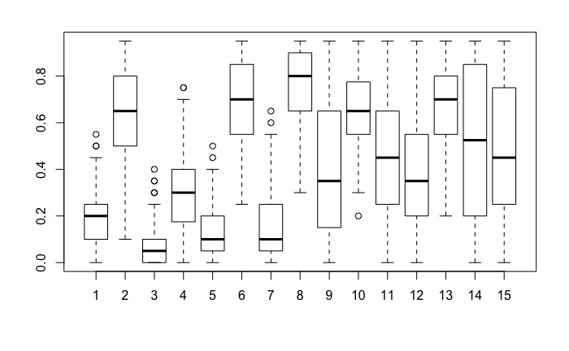

```r
# instead, load only a specific parameter
Lambda = load_posterior_param(BSFG_state,'Lambda')
# boxplots are good ways to visualize Posterior distributions on sets of related parameters
boxplot(BSFG_state$Posterior$F_h2[,1,])
```

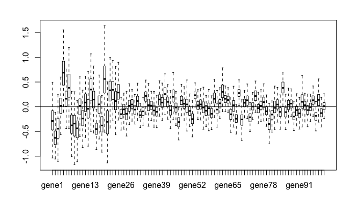

```r
# get posterior distribution on a function of parameters
# This is how to calculate the G-matrix for random effect #1 (ie animal above.)
G_samples = get_posterior_FUN(BSFG_state,Lambda %*% diag(F_h2['animal',]) %*% t(Lambda) + diag(resid_h2['animal',]/tot_Eta_prec[1,]))
# get posterior mean of a parameter
G = get_posterior_mean(G_samples)
# get Highest Posterior Density intervals for paramters
F_h2_HPD = get_posterior_HPDinterval(BSFG_state,F_h2)
boxplot(BSFG_state$Posterior$B1[,1,],outline=F);abline(h=0)
```

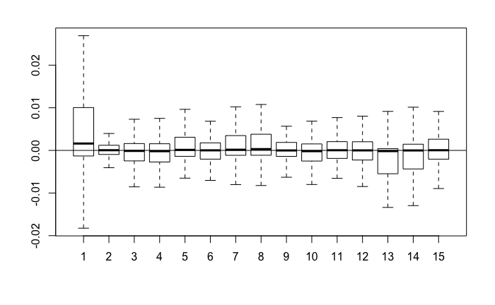

```r
boxplot(BSFG_state$Posterior$B2_F[,1,],outline=F);abline(h=0)
```